# UKB - Heteroplasmy, CHIP, and MN

02 - survival analysis for heteroplasmy or CHIP: Figure 4, Supplementary Table 3, Supplementary Figures 5-8, Supplementary Figure 10

Yun Soo Hong, Sergiu Pasca

November 03, 2024

# 1 Set up

## 1.1 Program description

- This program reads in the cleaned data set (`ukb_mthet_chip_dp3_2024_03_13.rds`), performs analysis in the “Mitochondrial heteroplasmy improves risk prediction for myeloid neoplasms” paper (Nature Communications, 2024), and provided the data used for generating tables and figures.
- This file contains
  - Figure 4, Supplementary Table 3, Supplementary Figures 5-8, Supplementary Figure 10.
- Steps
  - Step 1: Read in data
  - Step 2: Settings
  - Step 3: Figure 4
  - Step 4: Supplementary Table 3
  - Step 5: Supplementary Figure 5
  - Step 6: Supplementary Figure 6
  - Step 7: Supplementary Figure 7
  - Step 8: Supplementary Figure 8
  - Step 9: Supplementary Figure 10

## 1.2 Version of R and packages

## 1.3 Load libraries

```r
library(tidyverse)
library(magrittr)
library(lubridate)
library(stringr)
library(data.table)
library(survival)
library(survminer)
```

## 1.4 Print out settings

```r
options(tibble.print_max = 100)
options(pillar.sigfig = 5)
```

# 2 Load data

# 3 Settings

## 3.1 Excel output

```r
wb <- openxlsx::createWorkbook("")

# Add some sheets to the workbook
openxlsx::addWorksheet(wb, "Supplementary Table 3")
openxlsx::addWorksheet(wb, "Supplementary Figure 5")
openxlsx::addWorksheet(wb, "Supplementary Figure 6")
openxlsx::addWorksheet(wb, "Supplementary Figure 7")
openxlsx::addWorksheet(wb, "Supplementary Figure 8")
```

## 3.2 Survival analysis

### 3.2.1 Time to event

```r
summary(ukb$cancer_date_blood_mn)
```

```
##         Min.      1st Qu.       Median         Mean      3rd Qu.         Max.
## "2008-02-03" "2022-12-20" "2022-12-20" "2022-12-13" "2022-12-20" "2022-12-20"
```

```r
# all participants
ukb <-
  ukb |>
  mutate(
    time = as.numeric((cancer_date_blood_mn - dov)/365.25),
    end_date = case_when(
      # those who develop MN before death
      cancer_dx_blood_mn == 1 &
        (cancer_date_blood_mn <= date_of_death) ~ cancer_date_blood_mn,
      # those who die without developing MN
      death == 1 &
        (date_of_death < cancer_date_blood_mn) ~ date_of_death,
      # otherwise, administrative censoring
      TRUE ~ as.Date("2022-12-20")
    ),
    tt = as.numeric(end_date - dov)/365.25
  )
summary(ukb$tt)
```

```
##     Min.  1st Qu.   Median     Mean  3rd Qu.     Max.
##  0.01095 13.04586 13.78234 13.43854 14.49692 16.00274
```

```r
# CHIP positive
ukb_chip <-
  ukb |>
  filter(chip_yn == 1) |>
  mutate(
    chrs_cat = droplevels(chrs_cat)
  )

# CHIP negative
ukb_nochip <-
  ukb |>
  filter(chip_yn == 0)

# Heteroplasmy positive
ukb_het <-
  ukb |>
  filter(het_yn == 1) |>
  mutate(
    count_het_cat = droplevels(count_het_cat)
  )

# Heteroplasmy positive, CHIP positive
ukb_chip_het <-
  ukb_chip |>
  filter(het_yn == 1) |>
  mutate(
    count_het_cat = droplevels(count_het_cat)
  )

# Heteroplasmy positive, CHIP negative
ukb_nochip_het <-
  ukb_nochip |>
  filter(het_yn == 1) |>
  mutate(
    count_het_cat = droplevels(count_het_cat)
  )
```

### 3.2.2 Survival object

```r
surv <-
  with(ukb, Surv(time = tt, event = cancer_dx_blood_mn))

surv_chip <-
  with(ukb_chip, Surv(time = tt, event = cancer_dx_blood_mn))

surv_nochip <-
  with(ukb_nochip, Surv(time = tt, event = cancer_dx_blood_mn))

surv_het <-
  with(ukb_het, Surv(time = tt, event = cancer_dx_blood_mn))

surv_chip_het <-
  with(ukb_chip_het, Surv(time = tt, event = cancer_dx_blood_mn))

surv_nochip_het <-
  with(ukb_nochip_het, Surv(time = tt, event = cancer_dx_blood_mn))
```

# 4 Figure 4 - Risk of MN incidence based on CHIP and heteroplasmy status.

## 4.1 Panel A

### 4.1.1 KM curve

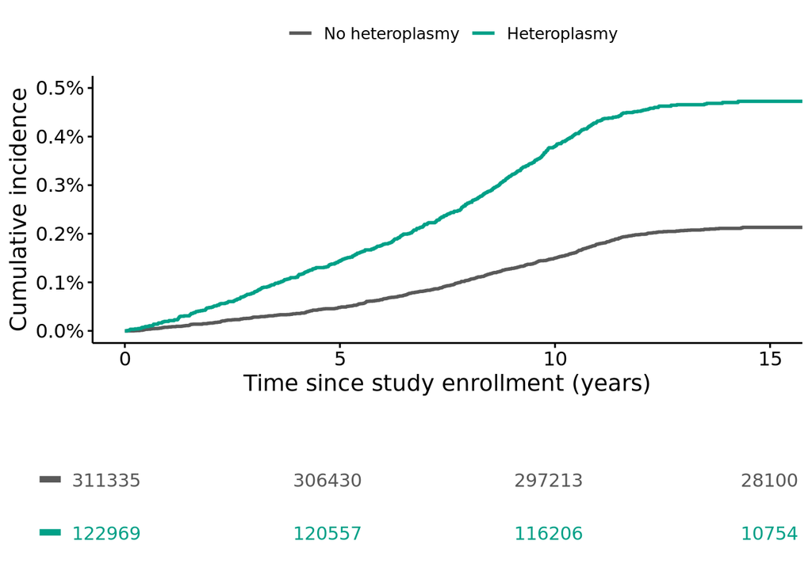

```r
km <- survfit(surv ~ het_yn, data = ukb)

survminer::ggsurvplot(
  km,
  censor = FALSE,
  risk.table = TRUE,
  risk.table.y.text = F,
  risk.table.y.text.col = T,
  risk.table.title = "",
  fontsize = 4,
  risk.table.col = "strata",
  risk.table.height = 0.3,
  tables.theme = theme_cleantable(),
  fun = "event",
  xlim = c(0, 15),
  ylim = c(0, 0.005),
  break.time.by = 5,
  surv.scale = "percent",
  legend.title = "",
  legend.lab = c("No heteroplasmy", "Heteroplasmy"),
  xlab = "Time since study enrollment (years)",
  ylab = "Cumulative incidence",
  palette = c("#595959FF", "#00A087FF")
)
```

### 4.1.2 Hazard ratios

```r
survival::coxph(surv ~ het_yn + rms::rcs(age, 5) + sex + smk_ever + prev_cancer_yn, data = ukb) |>
  summary()
```

```
## Call:
## survival::coxph(formula = surv ~ het_yn + rms::rcs(age, 5) +
##     sex + smk_ever + prev_cancer_yn, data = ukb)
##
##   n= 434304, number of events= 1191
##
##                            coef exp(coef) se(coef)      z Pr(>|z|)
## het_yn                  0.73192   2.07907  0.05817 12.582  < 2e-16 ***
## rms::rcs(age, 5)age     0.06001   1.06184  0.03431  1.749   0.0803 .
## rms::rcs(age, 5)age'    0.09993   1.10509  0.10748  0.930   0.3525
## rms::rcs(age, 5)age''  -0.50729   0.60212  0.41443 -1.224   0.2209
## rms::rcs(age, 5)age'''  1.33709   3.80795  0.76992  1.737   0.0824 .
## sexmen                  0.37650   1.45717  0.05885  6.398 1.58e-10 ***
## smk_everyes             0.15441   1.16697  0.06162  2.506   0.0122 *
## prev_cancer_yn          0.15426   1.16680  0.09742  1.583   0.1133
## ---
## Signif. codes:  0 '***' 0.001 '**' 0.01 '*' 0.05 '.' 0.1 ' ' 1
##
##                        exp(coef) exp(-coef) lower .95 upper .95
## het_yn                    2.0791     0.4810    1.8550     2.330
## rms::rcs(age, 5)age       1.0618     0.9418    0.9928     1.136
## rms::rcs(age, 5)age'      1.1051     0.9049    0.8952     1.364
## rms::rcs(age, 5)age''     0.6021     1.6608    0.2673     1.357
## rms::rcs(age, 5)age'''    3.8080     0.2626    0.8420    17.221
## sexmen                    1.4572     0.6863    1.2984     1.635
## smk_everyes               1.1670     0.8569    1.0342     1.317
## prev_cancer_yn            1.1668     0.8570    0.9640     1.412
##
## Concordance= 0.711  (se = 0.007 )
## Likelihood ratio test= 700.8  on 8 df,   p=<2e-16
## Wald test            = 651.8  on 8 df,   p=<2e-16
## Score (logrank) test = 752.1  on 8 df,   p=<2e-16
```